# Bush 631 - Quantitative Methods

Fall 2022

**Syllabus - the web version** (click tabs for more details on each section)

[figure not shown]

**The essentials**

#### When & Where

**Class Hours**: Tuesday 04:30-07:20 p.m.

**Office**: Allen 3029 (3rd floor)

**Classroom**: *Allen 1003*

**Office Hours**: Tuesday & Thursday 9:30-11:00 a.m.

#### Communication

The best place to ask questions is in the classroom. If your question is not related to class material or relevant to other students, we can discuss it after class. Outside the classroom, there are two ways to get in touch:

1. Office Hours: I encourage you to visit my office hours to discuss anything related to the course. I recommend watching [this Video (link)](https://vimeo.com/270014784) - it is both fun and offers some pointers on office hours. I am also available to meet outside of office hours, but you must contact me in advance so we can schedule a time that works for both of us.
2. Email: you can always email me with any concern you have (class-related or not). You can expect me to reply to emails within 24 hours during the work week. I will not reply to emails on the weekend, except for urgent matters. If the situation requires it, we can set-up a Zoom meeting and discuss the matter instead of via email. As with all business related correspondence, please include an appropriate salutation, identify yourself, and write in complete sentences.

**Lecturer**

Dr. Rotem Dvir

Email: rdvir@tamu.edu

PhD. TAMU Political Science (2021).

Assistant Research Scientist (Institute for Science Technology and Public Policy, Bush School)

A long time ago, I traveled to Australia and the South Pacific, here are a couple of amazing places I visited:

*White Heaven Beach (Australia)*

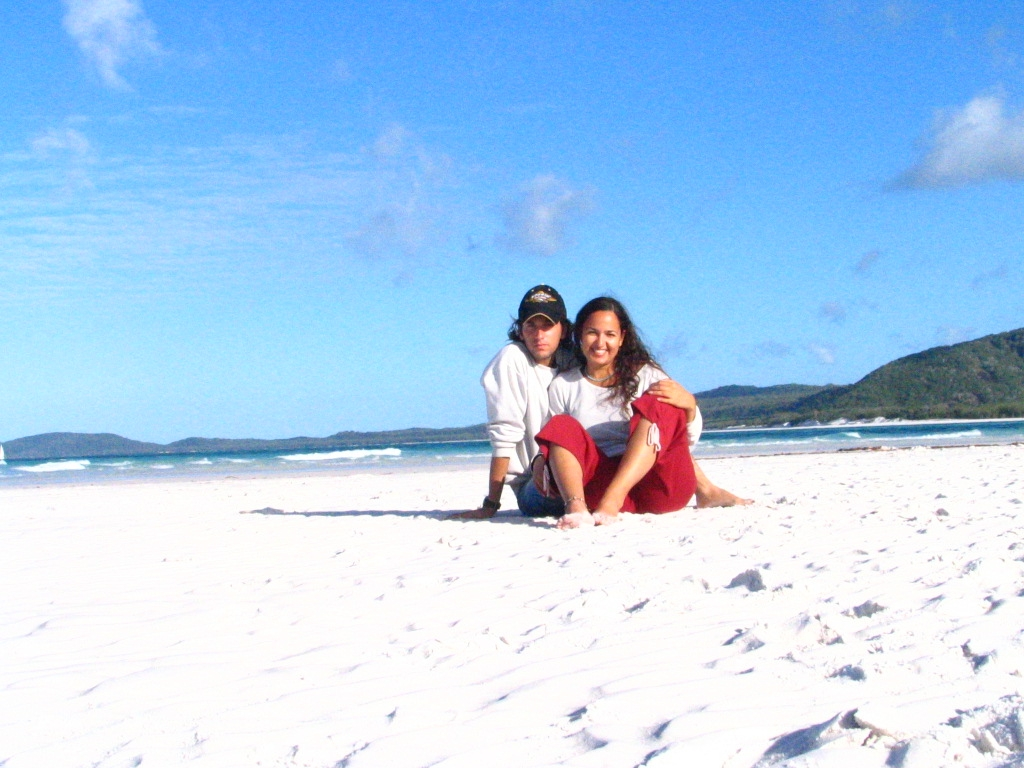

*Mt. Cook (New Zeland)*

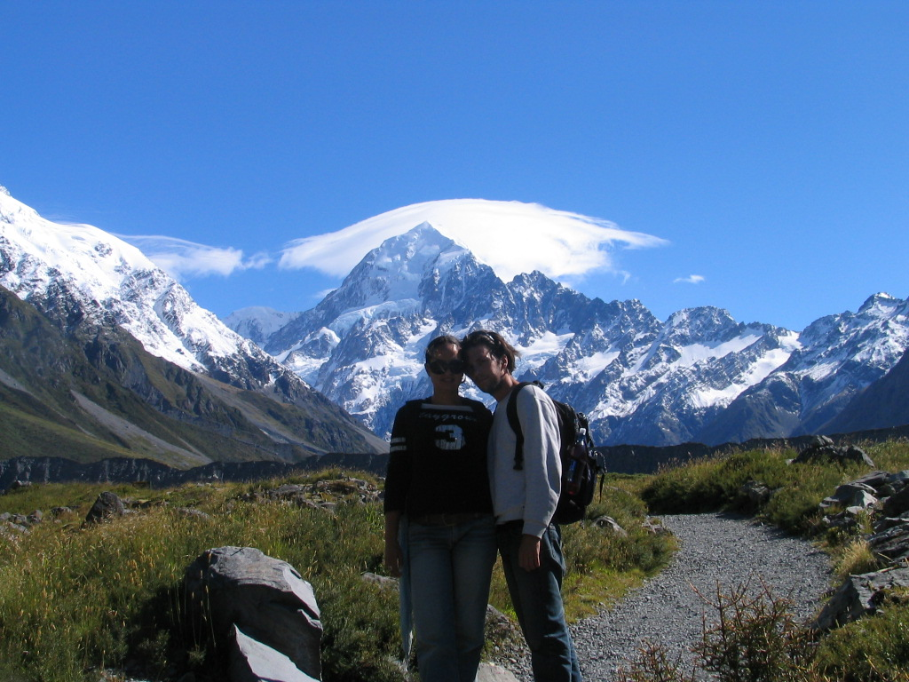

**About this Course**

This is a graduate course in quantitative social science research methods. We will learn about different methods to design research projects and use quantitative data to tackle a variety of questions in politics as a whole, and international affairs in particular. For example, how to predict election outcomes? What factors drive the onset of wars? What is the likelihood of a successful sanctions regime? Which type of leaders are more prone to concede in disputes? and how public opinion shape the decision to enter negotiations? You will obtain knowledge that is useful beyond academia. Many private companies and non-profits have invested heavily in data science techniques to learn about their users, platforms, markets, and programs. Data scientists at these institutions are essentially applied social scientists and employ many of the same techniques you will learn this semester.

The course covers the tools and techniques of building research designs. You will also obtain introductory statistical skills that are designed to give you an understanding of the appropriate uses (and mis-uses) of quantitative research. The goal is to provide you with the capability to understand, explain, and perform social science research, with a special focus on data analysis and causal reasoning. You will be able to read and understand how quantitative research methods are implemented in the social sciences. In addition, you will have a foot in the door of the data science world - this course will help you become proficient in the use of statistical software to manage and analyze data. The skills of collecting and analyzing data in a sophisticated manner have become crucial for the modern job market across industries. Finally, you will obtain data literacy that will help you become a critical consumer of evidence and information.

#### Course Objectives

1. Identify, understand and assess research designs, and their fit to the study of research questions in social sciences and international affairs.
2. Discuss methods of data collection (designing surveys and survey questions, determining sampling and sample size, etc.)
3. Develop data analysis skills including data management, exploration using descriptive statistics, generating and testing hypotheses using basic inferential statistics (by applying bivariate and multivariate models), as well as visualizing important findings.
4. Develop analytic skills to assess research designs that help understand events and processes in international affairs. Identify problems in applying quantitative data in the public realm.
5. Prepare written products for relevant professional audiences. Specifically, students will learn how to prepare written products such as executive summaries or reports, as well as visual presentations of their work.

### Required Readings

Textbook: Kosuke Imai. (2017). Quantitative Social Science: An Introduction.  
The book is available in the Texas A&M bookstore. You will need a copy of the book, otherwise it will be nearly impossible to pass the class. The book is comparatively affordable. Small number of copies of the book are available at the TAMU Evans and PSEL libraries.  
Reading assignments for each week of class are listed in the *Course Schedule* section of this syllabus. Reading assignments should be completed prior to the relevant meeting. Additional reading material is available through Internet links. Please note that some materials can only be accessed on computers connected to the University’s network.

Course Material Copyright: The handouts used in this course are copyrighted. By “Handouts,” I mean all materials generated for this class, which includes but are not limited to syllabi, slides, and tasks. Because these items are copyrighted, you do not have the right to copy handouts (or place them online), unless I expressly grant permission, which I have not. You do not have the right to electronically record (audio and/or video) any part of this class without the express, written consent of the instructor. You also do not have the right to post recordings of any portion of the class online or to distribute by other means.

**Grading & Attendance**

### Attendance & Participation

Class attendance will count for five (5) percent of your final grade. I expect you to actively participate in class discussions, ask questions, listen to your fellow students, and be attentive. Learning research methods is much easier when done in concert with others.

You are allowed to have one free unexcused absence from class. After one unexcused absence, I will deduct one point from the 5 possible attendance points for each unexcused absence. Excused absences are not deducted from your grade. I will decide what counts as excused on a case-by-case basis, but in general absences will only be excused for good reasons. You must contact me before missing class. If you have more than six (6) unexcused absences, you will receive an F in the course.  
If you do have any problems that do not allow you to perform well in class, please email me ASAP. I am willing to work with you, but this is only possible if you come talk to me early enough.

### Grading

Your grade for this course consists of the following:

1. Attendance (5%): as detailed in the section above.
2. Home (Swirl) assignments (10%): Short assignments that must be completed before the relevant class. These assignments are based on the textbook and are designed to help you better understood the materials covered in the textbook and class. You will receive a pass for the respective exercise as long as you attempt all questions. As proof, you will save a screenshot of the log at the end and submit it before the start of the class in which it is due.
3. Research Design task - using R (10%): In this task, you will use your knowledge of R software to analyze data provided by me. More details will be provided in class. Assignment due October 4, 2022.
4. Research Design and programming - class assignments (10%): You will complete a set of four (4) class tasks in which you will practice basic programming with R, and work with your colleagues to design research frameworks. Class assignments dates are detailed in the schedule section.
5. Research project - proposal (10%): In groups of maximum 2 students, you will prepare a project that explores a topic of interest in international affairs. For this research project, you will analyze a global phenomenon using data that you will collect, and then discuss the implications of your topic for American foreign policy. The first component of the project is a research proposal in which you discuss your selected topic, the plan for studying it, potential sources and data, and your final visual product. Proposal is due November 1, 2022.
6. Research project - data report (15%): Based on the topic and data you collected for the course research project, you will prepare a report that focuses on the data. You will be asked to describe the data, justify using it for your research project and conduct a preliminary analysis. More details will be provided in class. Assignment due November 15, 2022.
7. Research project - Infographic/Poster (25%): The main component of the course research project. You will prepare an inforgraphic / poster in which you present the topic and research question, as well as important findings and implications for policy. Presentations of your work will be scheduled for the first week of December 2022.
8. Research project - Executive summary (10%): In this component of the course research project, you will prepare an executive summary of your work. The document is intended to expand the information presented in your inforgraphic, and offer additional details on the topic for any consumer who may be interested. The executive summary document must be submitted along with the inforgraphic on the first week of December 2022.
9. Research project - peer review & feedback (5%): Each group / student would be required to review and provide constructive feedback for another group’s research project. Each group / student’s final version of the course project would be revised based on instructor feedback and these reviews. Peer review would be conducted during the final presentations on the first week of December 2022.
10. Research project - revised / edited: you will revise and edit your project (infographic and executive summary) based on the instructor feedback, and peer review comments. The final revised version is due December 12, 2022.

#### Grading Scale

Letter grades will be assigned as follows: all grades will be final and will not be changed unless the instructor has made a miscalculation.  
A: $\geq 89.5$  
B: $\geq 79.5 - < 89.5$  
C: $\geq 69.5 - < 79.5$  
D: $\geq 59.5 - < 69.5$  
F: $< 59.5$

#### Make-up Policy

Students will be allowed (in most cases, see Student Rule 7) to make-up tasks, provided that they email me within 24 hours of their absence. In addition, they must show original evidence of a university-excused absence or a letter from their dean explaining their absence (Please note that I do not accept Xeroxed copies of medical excuses from students). For instructions on how to obtain a letter from your dean regarding your excused absence, refer to Student Rule 7.2: “The associate dean for undergraduate programs, or the dean’s designee, of the student’s college may provide a letter for the student to take to the instructor stating that the dean has verified the student’s absence as excused” [Student Rule 7](http://student-rules.tamu.edu/rule07).

**Schedule and Readings**

**Note**

Any change to the syllabus is conducted advance notification.

**Important**

QSS below refers to your textbook.

#### Schedule

###### **Week 1**

Tuesday, August 30, 2022: Introduction

- *Required Reading*: QSS, Chapter 1 (pp. 1-31).
- *What’s the plan?*:
  - Course procedures, Canvas, Course website, office hours.
  - Introduction to R: download R and RStudio to your machine (instructions will be sent before class).

###### **Week 2**

Tuesday, September 6, 2022: Causality vol. I

- *Required Reading*: QSS, Chapter 2 (pp. 32-54, sections 2.1-2.4).
- *Recommended Reading*: Mattes, Michaela and Jessica Weeks (2019). “Hawks, Doves, and Peace: An Experimental Approach” *American Journal of Political Science*, 63 (1), pp. 53-66. [(Article Link)](https://doi.org/10.1111/ajps.12392)
- *What’s the plan?*:
  - The concept of causality in social science research, causal effects and counterfactuals.
  - Randomized experiments (RCTs).
  - R work: looking at our data, cross-tabs, relational operators, sub-setting data, factor variables.

###### **Week 3**

Tuesday, September 13, 2022: Causality vol. II

- *Required Reading*: QSS, Chapter 2 (pp. 54-74, sections 2.5-2.8).
- *Recommended Reading*: Fuhrmann, M., and Michael Horowitz. (2015). “When leaders matter: Rebel experience and nuclear proliferation.” *The Journal of Politics*, 77(1), 72-87. [(Article Link)](https://doi.org/10.1086/678308)
- *What’s the plan?*:
  - Expanding the discussion on the concept of causality in social science.
  - Observational studies.
  - R work: diff-in-means estimator, descriptive stats tools (mean,median, range, quantiles, standard deviation).
  - Class group task I - working with R

###### **Week 4**

Tuesday, September 20, 2022: Measurement vol. I

- *Required Reading*: QSS, Chapter 3 (pp. 75-96, sections 3.1-3.4).
- *Recommended Reading*: Sagan, S. and Benjamin Valentino. (2018). “Not just a war theory: American public opinion on ethics in combat.” *International Studies Quarterly*, 62(3), 548-561. [(Article Link)](https://doi.org/10.1093/isq/sqy033).
- *Recommended Reading*: Dvir, R., Geva, N. and Arnold Vedlitz. (2021). “Unpacking Public Perceptions of Terrorism: Does Type of Attack Matter?” *Studies in Conflict and Terrorism*, Online. [(Article Link)](https://doi.org/10.1080/1057610X.2021.1886427).
- *What’s the plan?*:
  - Measuring theoretical concepts - why? how? and some of the main challenges.
  - Tools for measurement: Surveys and samplng procedures.
  - R work: prop.table function, missing data (NAs), visuals (barplot, histogram, boxplot).
  - Class group task II - basic data exploration

###### **Week 5**

Tuesday, September 27, 2022: Measurement vol. II & Intro to Prediction

- *Required Reading*: QSS, Chapter 3 (pp. 96-122, sections 3.5-3.8) & Chapter 4 (pp. 123-139, section 4.1).
- *Recommended Reading*: Huff, C., and Joshua Kertzer. (2018). “How the public defines terrorism.” *American Journal of Political Science*, 62(1), 55-71. [(Article Link)](https://doi.org/10.1111/ajps.12329).
- *What’s the plan?*:
  - How to measure complex concepts.
  - Bivariate relationships, correlation, clustering.
  - Predictions with data (elections, defense spending): using the average value.
  - R work: visuals (scatterplot, QQ plot), z-score, correlation, matrix, list, k-means algorithm, loops, conditional statements.
  - Class group task III - Making plots

###### **Week 6**

Tuesday, October 4, 2022: Prediction vol. II

- *Required Reading*: QSS, Chapter 4 (pp. 139-161, section 4.2).
- *Recommended Reading*: Lin-Greenberg, E. (2019). “Backing up, not backing down: Mitigating audience costs through policy substitution.” *Journal of Peace Research*, 56(4), 559-574. [(Article Link)](https://doi.org/10.1177%2F0022343319832641).
- *What’s the plan?*:
  - Predicting with data (elections, international conflict and presidential approval).
  - Prediction based on linear regression models, model fit.
  - R work: predict, residuals, coef, merging datasets.
  - Data collection session I - Wendi Kasper (PSEL)
  - Submit Research Design task I by midnight!!

###### **Week 7**

Tuesday, October 18, 2022: Prediction vol. III

- *Required Reading*: QSS, Chapter 4 (pp. 161-188, sections 4.3-4.4).
- *Recommended Reading*: Schwartz, J. and Christopher Blair. (2020). “Do Women Make More Credible Threats? Gender Stereotypes, Audience Costs, and Crisis Bargaining.” *International Organization*, 74(4), 872-895. [(Article Link)](https://doi.org/10.1017/S0020818320000223).
- *Recommended Reading*: Fuhrmann, M. (2020). “When Do Leaders Free‐Ride? Business Experience and Contributions to Collective Defense.” *American Journal of Political Science*, 64(2), 416-431. [(Article Link)](https://doi.org/10.1111/ajps.12502).
- *What’s the plan?*:
  - Predicting with data (presidential approval, past experience and alliance contribution).
  - Prediction based on linear regression models - linearity, degrees of freedom, heterogeneous treatment effects.
  - R work: linear model function, levels for factor variable, interaction models.
  - Data collection session II - Wendi Kasper (PSEL)

###### **Week 8**

Tuesday, October 25, 2022: Probability vol. I

- *Required Reading*: QSS, Chapter 6 (pp. 242-277, sections 6.1-6.2).
- *Recommended Reading*: Edry, J., Johnson, J. and Ashley Leeds. (2021). “Threats at Home and Abroad: Interstate War, Civil War, and Alliance Formation.” *International Organization*, 75(3), 837-957. [(Article Link)](https://doi.org/10.1017/S0020818321000151).
- *What’s the plan?*:
  - Probability and modeling randomness, conditional probability, Bayes’s rule.
  - Components of probability theory - sample space, events,permutations, combinations.
  - R work: prop.table() for probabilities, sum of columns and rows.
  - Class group task IV - explore variables and their relationships

###### **Week 9**

Tuesday, November 1, 2022: Probability vol. II

- *Required Reading*: QSS, Chapter 6 (pp. 277-313, sections 6.3-6.5).
- *Recommended Reading*: Horowitz, M., McDermott, R., and Alan Stam. (2005). “Leader age, regime type, and violent international relations.” *Journal of Conflict Resolution*, 49(5), 661-685. [(Article Link)](https://doi.org/10.1177%2F0022002705279469).
- *What’s the plan?*:
  - Random variables and probability distributions, large sample theorems.
  - Probability mass function, cumulative density function, expectation, variance.
  - R work: density and probability functions, variance, simulations.
  - Submit research project proposal by midnight!!

###### **Week 10**

Tuesday, November 8, 2022: Estimation and Uncertainty vol. I

- *Required Reading*: QSS, Chapter Chapter 7 (pp. 314-342, section 7.1).
- *Recommended Reading*: Robinson, Kali. (2021). “What is the the Iran Nuclear Deal?” *Council of Foreign Relations website*. [(Article Link)](https://www.cfr.org/backgrounder/what-iran-nuclear-deal).
- *Recommended Reading*: Smeltz, D., Farmanesh, A., and Brendon Helm. (2021). “Iranians and Americans Support A Mutual Return to JCPOA”. *The Chicago Council on Global Affairs Report*. [(Article Link)](https://www.thechicagocouncil.org/research/public-opinion-survey/iranians-and-americans-support-mutual-return-jcpoa).
- *What’s the plan?*:
  - Important concepts in estimation: unbiasedness, consistency, margin of error.
  - Population and sample treatment effects, confidence intervals.
  - R work: simulations, loops, qnorm().

###### **Week 11**

Tuesday, November 15, 2022: Estimation and Uncertainty vol. II

- *Required Reading*: QSS, Chapter 7 (pp. 342-369, section 7.2).
- *Recommended Reading*: Scotto, T. J., & Reifler, J. (2017). “Getting tough with the dragon? The comparative correlates of foreign policy attitudes toward China in the United States and UK.” *International Relations of the Asia-Pacific*, 17(2), 265-299. [(Article Link)](https://academic.oup.com/irap/article/17/2/265/2525431?login=true).
- *What’s the plan?*:
  - Hypothesis testing, type I and type II errors, power analysis.
  - Null hypothesis, p-value, one-sample test, two-sample tests.
  - R work: simulations, fisher.test(), pnorm(), t.test().
  - Submit research project data report by midnight!!

###### **Week 12**

Tuesday, November 22, 2022: Estimation and Uncertainty vol. III

- *Required Reading*: QSS, Chapter 7 (pp. 370-390, section 7.3).
- *Recommended Reading*: Miller, S. (2014). “Reading a Regression Table: A Guide for Students”, *Steven Miller blog*. [(Link to Blog)](http://svmiller.com/blog/2014/08/reading-a-regression-table-a-guide-for-students/).
- *What’s the plan?*:
  - Uncertainty in linear regression models, inferences about coefficients.
  - Homoskedastic error, law of total variance.
  - R work: lm(), predict(), confint().

###### **Week 13**

Tuesday, November 29, 2022: Review & Summary

- *Recommended Reading*: Avey, P. C., Desch, M. C., Parajon, E., Peterson, S., Powers, R., & Tierney, M. J. (2021). “Does Social Science Inform Foreign Policy? Evidence from a Survey of US National Security, Trade, and Development Officials.” *International Studies Quarterly*. [(Article Link)](https://doi.org/10.1093/isq/sqab057).
- Probability and data in the real world: *Prediction by the numbers* [(Link)](https://www.youtube.com/watch?v=9OIel5NUG7Q)
- Probability and chance: *Tails you win* [(Link)](https://www.youtube.com/watch?v=sKiz5smpvE8)
- *What’s the plan?*:
  - Documentary: uncertainty, data and probability in real life.
  - Social science and International affairs research in the ‘real-world’: does it affect policy-making?
  - Review on all topics, time for Q & A.

###### **Week 14**

Tuesday, December 6, 2022: Final Projects presentations

- Projects event: **First week of December 2022** (tentative - pending department approval).
- *What’s the plan?*:
  - Present infographic / poster for 1 hour.
  - Complete peer review of research projects

**TAMU Policies**

#### Students with Disabilities

The Americans with Disabilities Act (ADA) is a federal anti-discrimination statute that provides comprehensive civil rights protection for persons with disabilities. Among other things, this legislation requires that all students with disabilities be guaranteed a learning environment that provides for reasonable accommodation of their disabilities. If you believe you have a disability requiring an accommodation, please contact Disability Services, currently located in the Disability Services building at the Student Services at White Creek complex on west campus or call 979-845-1637. For additional information visit http://disability.tamu.edu.

#### Academic Dishonesty/Plagiarism statement

As commonly defined, plagiarism consists of passing off as one’s own the ideas, words, writings, etc., which belong to another. In accordance with the definition, you are committing plagiarism if you copy the work of another person and turn it in as your own, even if you should have the permission of the person. Plagiarism is one of the worst academic sins, for the plagiarist destroys the trust among colleagues without which research cannot be safely communicated. If you have any questions regarding plagiarism or any other form of academic misconduct, please consult the Aggie Honor System Office website http://www.tamu.edu/aggiehonor or the latest version of the Texas A&M University Student Rules, under the section “Scholastic Dishonesty.” http://rules.tamu.edu.

**Remember**

An Aggie does not lie, cheat or steal, or tolerate those who do.

#### Diversity, equity and inclusion statement

The Department of International Affairs is committed to fostering a diverse, equitable, and inclusive learning environment for all students, staff, and faculty. We welcome individuals of all ages, backgrounds, citizenships, disabilities, ethnicities, family statuses, genders, gender identities, geographical locations, languages, military experiences, political views, races, religions, sexual orientations, socioeconomic statuses, and/or work experiences [see, http://diversity.tamu.edu/](http://diversity.tamu.edu/). We recognize a special responsibility to undertake particular efforts to include the participation and voices of those from historically underrepresented groups. In all of this, diversity alone is not the only goal; we also strive to hear, listen to, and incorporate new voices in our teaching, research, and service. We hold that embracing and supporting new perspectives, individuals, and ideas invigorates academic excellence and pushes our entire community forward. The Department of International Affairs and the Bush School expect everyone to demonstrate respect for different experiences, beliefs and values expressed by other members of our community and to engage in reasoned discussions. As a department of international affairs, within a university dedicated to the public good, a commitment to diversity, equity, and inclusion is critical for preparing and ensuring the success of the next generation of leaders.

#### Title IX Statement on Limits to Confidentiality

Texas A&M University is committed to fostering a learning environment that is safe and productive for all. University policies and federal and state laws provide guidance for achieving such an environment. Although class materials are generally considered confidential pursuant to student record policies and laws, University employees - including instructors - cannot maintain confidentiality when it conflicts with their responsibility to report certain issues that jeopardize the health and safety of our community. As the instructor, I must report (per Texas A&M System Regulation 08.01.01) the following information to other University offices if you share it with me, even if you do not want the disclosed information to be shared: Allegations of sexual assault, sexual discrimination, or sexual harassment when they involve TAMU students, faculty, or staff, or third parties visiting campus.  
These reports may trigger contact from a campus official who will want to talk with you about the incident that you have shared. In many cases, it will be your decision whether or not you wish to speak with that individual. If you would like to talk about these events in a more confidential setting, you are encouraged to make an appointment with the Student Counseling Service https://scs.tamu.edu/. Students and faculty can report non-emergency behavior that causes them to be concerned at http://tellsomebody.tamu.edu.

#### TAMU Writing Center

The University Writing Center (UWC) is here to help you develop and refine the communication skills important to your success in college and beyond. The UWC provides this help in a welcoming atmosphere that respects all Aggies backgrounds and abilities. Our trained peer consultants are available to work with you on any kind of writing or speaking project, including research papers, lab reports, application essays, or creative writing, and at any stage of your process, whether you’re deciding on a topic or reviewing your final draft. You can also get help with public speaking, presentations, and group projects. We can work with you in person at our Evans or BLCC locations or via Zoom or email. To schedule an appointment or to view our handouts, videos, or interactive learning modules, visit writingcenter.tamu.edu. If you have questions, need help making an appointment, or encounter difficulty accessing our services, call 979-458-1455 or email uwc@tamu.edu.

#### COVID-19 Statement

To help protect Aggieland and stop the spread of COVID-19, Texas A&M University urges students to be vaccinated and to wear masks in classrooms and all other academic facilities on campus, including labs. Doing so exemplifies the Aggie Core Values of respect, leadership, integrity, and selfless service by putting community concerns above individual preferences. COVID-19 vaccines and masking — regardless of vaccination status — have been shown to be safe and effective at reducing spread to others, infection, hospitalization, and death.

#### Less official pandemic stuff

Texas A&M University does not have a mask or vaccination mandate, but as the previous statement mentions, it is highly recommended.  
If that makes you feel safer, you are more than welcome to wear a mask in class (regardless of your vaccination status).  
I will place a box of disposable masks by the door if you would like one.

Again, Texas A&M University does not require either vaccines or masks, and if you are not vaccinated or do not wear a mask, there are no penalties.

**Fun Syllabus Task**

If you read everything to this point, that’s great! 💪

Please 🙏 email me (by Monday August 29th) your home state (or country if not an American), and I promise I will use it as data for class!!.